# Behavioural repeatability results

07 May, 2025

### Sample sizes

We know age effects behaviour, and individuals are recorded at different ages, so this is included in the repeatability models and hence the dataset has been filtered to exclude individuals of unknown age. We don’t worry about sex, as each individual can only be one sex. We are also only using individuals with more than one season of data, as otherwise we can’t calculate across season repeatability.

Table 1. Sample sizes for each species and colony, showing the number of individuals for which we have 2, 3, or 4+ seasons of data.

[output not shown]

## Testing for repeatablity

This analysis looks at repeatability in foraging behaviours. I am looking at seven behavioural variables:

1. *duration.hrs* = Duration of the foraging trip in hours
2. *transitions* = Number of transitions between rest and flight and vice versa
3. *transit_time.pct* = Percentage of foraging trip spent in flight
4. *rest_time.pct* = Percentage of foraging trip spent in rest
5. *total_distance.km* = Total distance covered over the trip, in km
6. *max_distance.km* = Maximum foraging range (measured from colony), in km
7. *transit_to_rest.ratio* = Ratio of flight to rest time; >1 = more flight than rest, <1 = more rest than flight

I have then written my own repeatability functions, which explicitly partition repeatability into **annual** repeatability (season level), **within-season** repeatabilty (ring:season level) and **between-season** repeatability (ring level). This is because *rptR* doesn’t natively handle this kind of decomposition - it can only estimate repeatabilty for a single grouping factor at a time.

In my functions, I manually boostrap confidence intervals and SEs around repeatability by resampling the data and refitting models:

*To estimate uncertainty around repeatability estimates, we implemented a nonparametric bootstrap procedure with 1000 iterations. In each iteration, the dataset was resampled with replacement, the linear mixed-effects model was refitted, and variance components were extracted. We calculated repeatability for each iteration as the proportion of variance explained at the relevant grouping level (ring, season, or ring:season). From the resulting distributions, we computed mean estimates, standard errors, and 95% confidence intervals based on the 2.5th and 97.5th percentiles.*

The basic formula used in this analysis is:

$$y = \beta_0 + \beta_1 \cdot \text{phase}
+ \beta_2 \cdot \text{age} + \beta_3 \cdot \text{colony} +
U_{\text{ring}} + U_{\text{season}} + U_{\text{ring:season}} +
\varepsilon$$

where:

- $y$ represents each of the 7 behavioural response variables,
- $\beta_0$ is the intercept,
- $\beta_1$ - $\beta_{3}$ are fixed effect coefficients for $phase$, $age$, and $colony$,
- $U_{\text{ring}}$, $U_{\text{season}}$, and $U_{\text{ring:season}}$ are random intercepts for ring, season, and ring within season respectively,

  $$U_{\text{ring}} \sim \mathcal{N}(0,
  \sigma^2_{\text{ring}})$$

  $$U_{\text{season}} \sim \mathcal{N}(0,
  \sigma^2_{\text{season}})$$

  $$U_{\text{ring_season}} \sim
  \mathcal{N}(0, \sigma^2_{\text{ring_season}})$$
- $ε$ is the residual error.

  $$ε \sim \mathcal{N}(0,
  \sigma^2_{\text{res}})$$

Several of the predictor values have positive-skewed distributions with heavy tails. As I’m not interested in predictions, a simple and stable approach to dealing with this is simply to **log-transform** $y$ in each model. The only exception for this is *transit_time.pct*, which, even though it is a percentage, it is relatively normally distributed, the residuals look good, and the values are comfortably away from the 0 to 100 boundaries (i.e. mostly between 20 and 80). The distribution of *rest_time.pct* is a little problematic - the values are right skewed with a very long tail towards high values and lots of values around 0. Possibly a beta model would be a better fit here. But for ease of computation, I’m pursuing the log transformation for now. The variances don’t look super different between this and a beta model.

### Repeatability results

Table 2. Repeatability parameters for each species. Sample sizes are for trips, individuals.

| species | parameter | annual_var | annual_R | annual_ci | within_var | within_R | within_ci | between_var | between_R | between_ci | sample_size |  |  |
| --- | --- | --- | --- | --- | --- | --- | --- | --- | --- | --- | --- | --- | --- |
| BBAL | duration.hrs | 0.02 | 0.058 ± 0.058 | [0.0034, 0.21] | 0.06 | 0.13 ± 0.02 | [0.095, 0.17] | 0.04 | 0.06 ± 0.016 | [0.031, 0.091] | 4351, 250 |  |  |
|  | transitions | 0.00 | 0.017 ± 0.024 | [0, 0.092] | 0.07 | 0.15 ± 0.019 | [0.11, 0.19] | 0.05 | 0.055 ± 0.015 | [0.027, 0.085] |  |  |  |
|  | rest_time.pct | 0.05 | 0.079 ± 0.014 | [0.053, 0.11] | 0.06 | 0.14 ± 0.014 | [0.11, 0.16] | 0.03 | 0.059 ± 0.013 | [0.034, 0.085] |  |  |  |
|  | transit_time.pct | 54.13 | 0.19 ± 0.026 | [0.14, 0.24] | 34.82 | 0.17 ± 0.018 | [0.13, 0.21] | 24.00 | 0.094 ± 0.021 | [0.055, 0.14] |  |  |  |
|  | transit_to_rest.ratio | 0.19 | 0.15 ± 0.023 | [0.11, 0.2] | 0.15 | 0.17 ± 0.017 | [0.14, 0.21] | 0.09 | 0.078 ± 0.019 | [0.04, 0.12] |  |  |  |
|  | max_distance.km | 0.00 | 0.012 ± 0.039 | [0, 0.14] | 0.12 | 0.41 ± 0.14 | [0.13, 0.66] | 0.11 | 0.28 ± 0.13 | [0.015, 0.53] |  | 247, 101 |  |
|  | total_distance.km | 0.07 | 0.12 ± 0.14 | [0, 0.51] | 0.09 | 0.37 ± 0.24 | [0, 0.84] | 0.11 | 0.36 ± 0.28 | [0, 0.9] |  |  |  |
| WAAL | duration.hrs | 0.04 | 0.028 ± 0.011 | [0.0088, 0.05] | 0.12 | 0.15 ± 0.015 | [0.12, 0.18] | 0.10 | 0.089 ± 0.012 | [0.065, 0.11] |  |  | 7928, 359 |
|  | transitions | 0.03 | 0.025 ± 0.011 | [0.0038, 0.048] | 0.08 | 0.12 ± 0.015 | [0.092, 0.15] | 0.08 | 0.069 ± 0.0099 | [0.051, 0.09] |  |  |  |
|  | rest_time.pct | 0.00 | 0.0029 ± 0.0025 | [0, 0.0089] | 0.04 | 0.11 ± 0.014 | [0.088, 0.14] | 0.02 | 0.034 ± 0.0092 | [0.016, 0.051] |  |  |  |
|  | transit_time.pct | 3.88 | 0.012 ± 0.0063 | [0.0011, 0.026] | 29.60 | 0.16 ± 0.019 | [0.13, 0.2] | 11.04 | 0.034 ± 0.014 | [0.0085, 0.061] |  |  |  |
|  | transit_to_rest.ratio | 0.00 | 0.0029 ± 0.0029 | [0, 0.0099] | 0.12 | 0.15 ± 0.019 | [0.12, 0.19] | 0.06 | 0.037 ± 0.012 | [0.014, 0.061] |  |  |  |
|  | max_distance.km | 0.02 | 0.035 ± 0.034 | [0, 0.12] | 0.00 | 0.25 ± 0.086 | [0.082, 0.42] | 0.09 | 0.13 ± 0.07 | [0, 0.27] |  | 308, 118 |  |
|  | total_distance.km | 0.02 | 0.046 ± 0.064 | [0, 0.21] | 0.19 | 0.81 ± 0.13 | [0.46, 0.97] | 0.00 | 0.026 ± 0.088 | [0, 0.33] |  |  |  |

Figure 1. Summary of bootstrapped repeatability values for each species. Grey intervals indicate R < 0.1 (darker interval), where repeatability is deemed to be neglibile, and 0.1 < R < 0.3, where repeatabiltiy is deemed to be low-modest. Repeatability values greater than this may be considered biologically interesting.

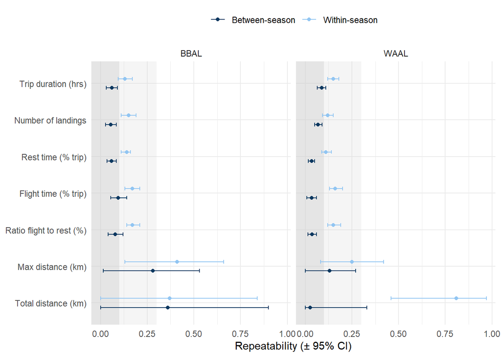